# Introduction to R and dynamic modeling

Forrest W. Crawford

# Computer preparation

For this course, we will use R for instruction. Of course, you can use any language you want for your own projects or for this course, but the course materials – slides and case studies – use R, and we can best assist you if you are using R.

Our goal in this session is to make sure everyone has the R statistical computing environment running on their computer, and to do some basic simulations for ODE models.

## Install R

Go to http://www.r-project.org and click download R.

It may ask you to choose a CRAN mirror (i.e. an R distribution site). Scroll down to USA and click any of the links associated with a nearby institution.

Under “download and install R,” choose the option that is relevant for your operating system.

If you are on a Mac running OSX 10.6 or later, click on “Download R for (Mac) OS X.” Next read the information below “Files” to choose the right file for your operating system. You should choose one of the first two files (“R-…pkg”).

If you are running an older operating system and do not already have R, you may choose to either download an older version of R (see the word “old” highlighted in blue at the top of the page) or update your operating system. If you are unable to do either, please contact us.

If you are on a Windows computer, click “Download R for Windows.” On the next page below where it says “subdirectories” click “base.” On the next page, click the link at the top of the page to download R for Windows.

Follow the instructions to install R.

## Install RStudio

We recommend that you use the RStudio development environment. It is somewhat easier than using the R console that comes with basic R downloaded from CRAN. This is optional, but recommended for new R users.

https://www.rstudio.com/products/rstudio/download/#download

## Install packages

Once you have downloaded R and installed it (and possibly RStudio), you will need several additional packages. Start R and type in the command line:

```r
update.packages()
install.packages(c("GillespieSSA", "deSolve", "tidyverse"), dependencies = TRUE)
```

Ask the TAs if you encounter any issues installing R or the packages.

# Working with R

You will interact with R mostly via the console, or command line.

You can also write R scripts, which are text documents containing R code that you can ask R to run all at once.

## The basics

There are two main R screens we may be working in: the command line (aka R console) and R documents (aka R scripts).

The command line is what you see when you first open R. When you input code here and hit “return,” R executes the command you have given it. For example, try writing

```r
2 + 2
```

```
## [1] 4
```

## R Documents

You can open an R document by going to File -> New Document (on a Mac) or File -> New Script (on Windows). In an R document, you can write and edit multiple lines of code. R will not run this code until you copy and paste it into the command line. You can save R documents and open them again later.

In this course, we will frequently give you R files to run as they are. To do this, save the file in the folder you want. Next open R and change your working directory to that folder. Then go to File -> Open Document (on a Mac) or File -> Open Script (on a Windows) and choose the file you want to run. Select all of the document, copy it, paste it into the command window, and hit return. Your code should run successfully!

## Working Directory

Create a folder/directory on your computer for this course. For example `/Users/forrest/Documents/phmodeling` on a Mac, or `C:\Users\Forrest\Documents`.

Your working directory is the default file that R uses when you want to open files, read in files, or save files. The first thing you should do when opening R is to change your working directory to the folder you want to work in. On a Mac, you do this by going to Misc -> Change Working Directory. On a Windows computer, you do this by going to File -> Change Dir.

Change your working directory to the folder you created for this course.

## Basics

If you already know how to use R, you can skip this section and go directly to the modeling part below.

If you do not have experience with R, the following brief tutorial outlines some of the basic features of the R language, its syntax, and built-in functions.

### Variable assignment

Variable assignment in R is easy, and variable types do not generally need to be defined in advance. To assign the value `7` to the variable `x`, you can write

```r
x = 7
x <- 7
```

The `<-` assignment operator is mostly like `=`. We will primarily use `=` in this course.

### Arithmetic

Scalar arithmetic in R mostly works as you have seen in other languages

```r
1 + 1
```

```
## [1] 2
```

```r
2 * 3
```

```
## [1] 6
```

```r
3^4
```

```
## [1] 81
```

```r
6/2
```

```
## [1] 3
```

## Binary operators

```r
1 < 2
```

```
## [1] TRUE
```

```r
1 <= 1
```

```
## [1] TRUE
```

### Logical operators

```r
# logical AND
1 < 2 && 4 < 5
```

```
## [1] TRUE
```

```r
# logical OR
4 < 2 || 4 < 5
```

```
## [1] TRUE
```

R has the usual mathematical functions and constants

```r
exp(1)
```

```
## [1] 2.718282
```

```r
log(1)
```

```
## [1] 0
```

```r
sin(pi)
```

```
## [1] 1.224647e-16
```

```r
factorial(5)
```

```
## [1] 120
```

```r
choose(5, 3)
```

```
## [1] 10
```

```r
round(pi, digits = 2)
```

```
## [1] 3.14
```

```r
mean(1:10)
```

```
## [1] 5.5
```

```r
sd(1:10)
```

```
## [1] 3.02765
```

```r
sum(1:10)
```

```
## [1] 55
```

R has a few special types that you may see: `Inf`, for infinity, `NaN` for not-a-number and `NA` for missing values.

```r
Inf
```

```
## [1] Inf
```

```r
0/0
```

```
## [1] NaN
```

```r
NA
```

```
## [1] NA
```

Operations with these quantities work mostly as expected:

```r
Inf + 1
```

```
## [1] Inf
```

```r
NaN + 1
```

```
## [1] NaN
```

```r
NA + 1
```

```
## [1] NA
```

```r
Inf - Inf
```

```
## [1] NaN
```

```r
NaN + NA
```

```
## [1] NaN
```

```r
1/Inf
```

```
## [1] 0
```

```r
Inf/Inf
```

```
## [1] NaN
```

### Characters and strings

Strings are double- or single-quoted

```r
mystr = "lettuce"
mychar = "tomatoes"
```

### Vectors

You can create vectors using the “concatenate” function

```r
x = c(1, 3, 9)
```

Vectors can have named elements

```r
x = c(a = 1, b = 2)
```

You can create a vector consisting of a sequence of numbers using the `:` operator

```r
1:10
```

```
##  [1]  1  2  3  4  5  6  7  8  9 10
```

Be careful with the `:` operator and arithmetic:

```r
n = 10
# which do you want:
1:n - 1
```

```
##  [1] 0 1 2 3 4 5 6 7 8 9
```

```r
1:(n - 1)
```

```
## [1] 1 2 3 4 5 6 7 8 9
```

You can use the `seq` function for finer control over sequences

```r
x = seq(0, 10, by = 0.5)
y = seq(0, 10, length.out = 6)
```

### Matrices

You can create a matrix as follows

```r
m = matrix(1:9, nrow = 3, ncol = 3)
```

Note that the first argument to the `matrix` function is a vector of numbers; these are filled into the matrix column-wise unless the `byrow=TRUE` argument is specified.

### Matrix/vector arithmetic

```r
x = 1:3
y = 7:9

# element-wise multiplication
x * y
```

```
## [1]  7 16 27
```

```r
# dot product
x %*% y
```

```
##      [,1]
## [1,]   50
```

```r
A = matrix(1:9, nrow = 3)


# this is matrix-vector multiplication
A %*% x
```

```
##      [,1]
## [1,]   30
## [2,]   36
## [3,]   42
```

R does some strange things when you ask it to multiply objects with incompatible dimensions.

```r
# this does NOT give an error
A * x
```

```
##      [,1] [,2] [,3]
## [1,]    1    4    7
## [2,]    4   10   16
## [3,]    9   18   27
```

In this example, “element-wise” left-multiplication of a matrix by a vector gives column-wise multiplication. Beware!

### Indexing

To get the `i`th element of a vector `x`, use `x[i]`. To get the `i,j` element of a matrix `A`, use `A[i,j]`.

```r
x[2]
```

```
## [1] 2
```

```r
A[2, 3]
```

```
## [1] 8
```

```r
A[1:3, 2]
```

```
## [1] 4 5 6
```

### Logical indexing

Instead of a numeric index to a vector or matrix, you can use logical indexing via a binary operation that returns TRUE or FALSE.

```r
x = 1:10
y = runif(10)

# get the values of x that are <= 5
x[x <= 5]
```

```
## [1] 1 2 3 4 5
```

```r
# get the values of x for which that element of y is less
# than 0.5
x[y < 0.5]
```

```
## [1] 1 2 5 8
```

### Binding

You can combine objects (vectors, matrices) of compatible dimension row-wise or columnwise, to get a new matrix

```r
x = 1:3
y = 4:6
rbind(x, y)
```

```
##   [,1] [,2] [,3]
## x    1    2    3
## y    4    5    6
```

```r
cbind(x, y)
```

```
##      x y
## [1,] 1 4
## [2,] 2 5
## [3,] 3 6
```

### Lists

R has a special data structure, called a `list` that can hold many types of objects

```r
mylist = list(a = matrix(1:4, nrow = 2), b = "donuts")
```

You can access list elements like this:

```r
mylist$a
```

```
##      [,1] [,2]
## [1,]    1    3
## [2,]    2    4
```

```r
mylist$a[2, 1]
```

```
## [1] 2
```

```r
mylist$b
```

```
## [1] "donuts"
```

## Functions

To make a function in R, use the following syntax

```r
myfun = function(x) {
    y = x * x
    return(y)
}
```

Now you can call this function as follows:

```r
myfun(7)
```

```
## [1] 49
```

Function arguments can have default values,

```r
myfun2 = function(x = 2) {
    y = x * x
    return(y)
}
```

Now you can call `myfun2` with no arguments, and the default argument `x=2` will be used.

```r
myfun2()
```

```
## [1] 4
```

To learn more about any built-in (or package) function, type

```r
`?`(function_name)
```

and you will see the manual page for `function_name`.

## Probability distributions

All of the familiar probability distributions are built into R. For any distribution, you can generate random values, evaluate the probability mass function or density, evaluate the cumulative distribution function, or compute quantiles, using similar syntax. For example, to generate $n=10$ independent normally distributed random values with mean 0 and SD 1, use `rnorm

```r
rnorm(n = 10, mean = 0, sd = 1)
```

```
##  [1]  2.111789118 -0.323291322  0.266386741 -0.002862404 -0.017499982
##  [6] -1.351518919  0.702956534 -0.825039613  0.405328175 -1.500143664
```

To evaluate the normal density,

```r
dnorm(0, mean = 0, sd = 1)
```

```
## [1] 0.3989423
```

cumulative distribution function,

```r
pnorm(0, mean = 0, sd = 1)
```

```
## [1] 0.5
```

and quantile

```r
qnorm(0.5, mean = 0, sd = 1)
```

```
## [1] 0
```

Other useful distributions for which these `r`, `d`, `p`, and `q` functions are available:

```r
exp
beta
unif
pois
binom
```

and many more.

The `sample` function is an easy way to draw a random value from a set of values.

```r
x = 1:10
p = runif(10)

# draw one value from x uniformly at random
sample(x, 1)
```

```
## [1] 3
```

```r
# draw one value from x with probability proportional to its
# element of `p`
sample(x, 1, prob = p)
```

```
## [1] 2
```

Beware: if `x` is a scalar, `sample` will draw instead from the intgegers `1:floor(x)`.

By default, if the number of samples desired is greater than 1, `sample` will draw values *without replacement*. You can use the argument `replace=TRUE` to draw samples larger than the number of elements in `x`.

## Data frames

R uses data frames to store data of mixed types, where each entry is a row, and each column is a variable.

```r
dat = data.frame(x = rnorm(10), y = 1:10)
```

You can access the columns of a data frame like this:

```r
dat$y
```

```
##  [1]  1  2  3  4  5  6  7  8  9 10
```

or using the usual matrix indexing syntax,

```r
dat[2, 2]
```

```
## [1] 2
```

### if/else

Conditional logic works mostly as expected:

```r
z = runif(1)
y = NA
if (z < 0.5) {
    y = "small"
} else {
    y = "big"
}
y
```

```
## [1] "small"
```

### Loops

`for` and `while` loops work as expected:

```r
for (i in 1:10) {
    i
}

i = 1
while (i < 10) {
    i = i + 1
}
```

You can use `break` to escape from a loop, and `next` to skip to the next iteration.

### Not covered

In this brief tutorial, we have covered basic syntax and usage of R, but not any of its more sophisticated capaibilities.

- plotting – you will see examples as we proceed
- tidyverse, including `dplyr` and `ggplot`
- statistical models and regression utilities
- more complex data structures, like multi-dimensional arrays
- parallel computaion
- interactive visualizations

## Help

You can access R function help files using a question mark before the function name of interest. For example if I wanted to know how the `mean` function worked, I could enter

```r
`?`(mean)
```

into the R command line and a help file would appear.

# Running a simple SI model with vital dynamics

Consider a simple deterministic Susceptible-Infective model with individuals born into the susceptible category with rate $\lambda$, and dying with rates $\mu_s$ for susceptibles and $\mu_i$ for infectives. We can write this ODE system as follows.

$$\begin{aligned}
\frac{dS}{dt} = \lambda - \beta S(t) I(t) - \mu_s S(t) \\
\frac{dI}{dt} = \beta S(t) I(t) - \mu_i I(t)
\end{aligned}$$

Make sure you understand the dyanmics implied by this system.

When you are ready, run the following code in R. Make sure you understand the relationship between the equations above and the `SI_model` function below.

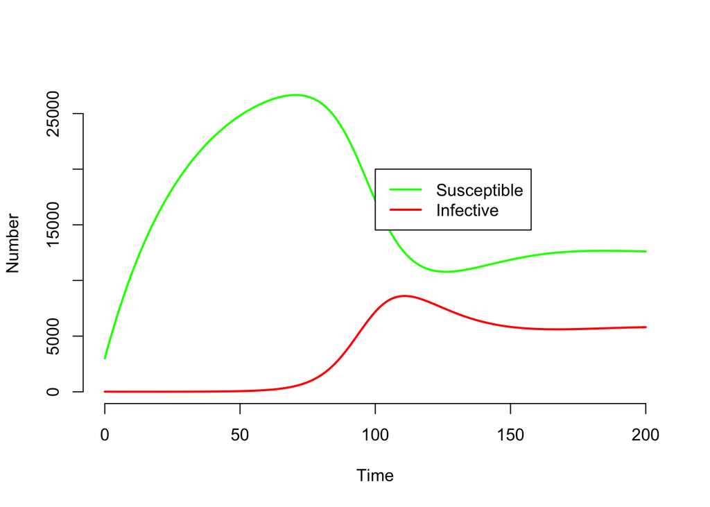

```r
library(deSolve)

######################## SI Model ########################

SI_model <- function(times, yinit, pars) {
    with(as.list(c(yinit, pars)), {
        dS <- lam - beta * I * S - mu_s * S
        dI <- beta * I * S - mu_i * I
        return(list(c(dS, dI)))
    })
}

################## Setting Parameters ##################

beta = 8e-06  # beta is transmission parameter
mu_s = 1/30  # mu_s is the mortality rate for susceptibles
mu_i = 1/10  # mu_i is the mortality rate for infecteds
lam = 1000  # lam is the birth rate (assumed not to depend on population size)
pars <- cbind(lam, beta, mu_s, mu_i)

############### Setting Time Frame ####################

start_time = 0  # start date
end_time = 200  # end date
times <- seq(start_time, end_time, by = 1)  # gives a sequence from start to end

############ Setting Initial Conditions ###############

yinit <- c(S = 3000, I = 10)

############# Running The Model ####################

results <- as.data.frame(ode(y = yinit, times = times, func = SI_model,
    parms = pars, method = "rk4"))

############# Plotting Results ######################

plot(results$time, results$S, col = "green", type = "l", bty = "n",
    lwd = 2, xlab = "Time", ylab = "Number", ylim = range(c(results$S,
        results$I)))
lines(results$time, results$I, col = "red", lwd = 2)
legend(100, 20000, c("Susceptible", "Infective"), col = c("green",
    "red"), lwd = 2)
```

# Questions

1. Try to explain qualitatively why the $S(t)$ and $I(t)$ trajectories look the way they do.
2. How is this setting different from the standard SI model we saw earlier?
3. How sensitive are the trajectories to different birth and death rates?
4. Can you modify the code to produce trajectories from an SIR model with similar vital dynamics?